# SAIL Report

Stellen Li

2023-01-15

## Introduction

In college basketball, March Madness is the biggest tournament each year, and it’s known for its crazy upsets and sometimes a team’s complete domination. However, I have always wondered if there’s a trend for how a team will perform in the tournament and whether or not certain variables can predict a team’s power ranking. Of course, knowing such statistics will not completely reshape a team, but it will provide insights to what teams should look for as they prepare for future seasons. Additionally, by completing an exploratory data analysis, we can see that there are a lot of analyses that can still be done to further understand potential applications of other variables in the dataset that was used.

In this report, I will look at a college basketball dataset and explore which variables can help predict a team’s success in the March Madness Tournament. In order to do so, I will first look for correlations between bubble teams and non-bubble teams (teams that did not make the cut for the March Madness Tournament). Then, I will use a Backward Elimination process to finalize the variables, making sure there does not exist a problem with statistical significance. At last, I will also use Lasso, Ridge, and a mixed regression model to determine how accurate and reliable these variables are.

## Data

For the data, I used Andrew Sundberg’s College Basketball Dataset via Kaggle. This dataset contains information about each NCAA Division I team from 2013-2021 (excluding 2020 due to not having a postseason from Covid-19). These data include a team’s number of games, wins, win percentages, Adjusted Efficiency, Power Rating, Effective Goal Percentages, Turnover Percentages, Offensive Rebound Rates, Free throw Rates, Two-point Shooting percentages, Three-Point Shooting Percentages, Adjusted Tempo, Wins Above the Bubble, Postseason results, and Seed. For clarifications, Adjusted Efficiency is calculated by Adjusted Offensive Efficiency - Adjusted Defensive Efficiency, and win percentages are calculated by dividing the number of wins by total number of games played. There is a total of 26 variables, but I am only focusing on numerical variables for the sake of Backward Elimination, Lasso, and Ridge Regression models. The following table displays the important variables from the this original dataset and their descriptions.

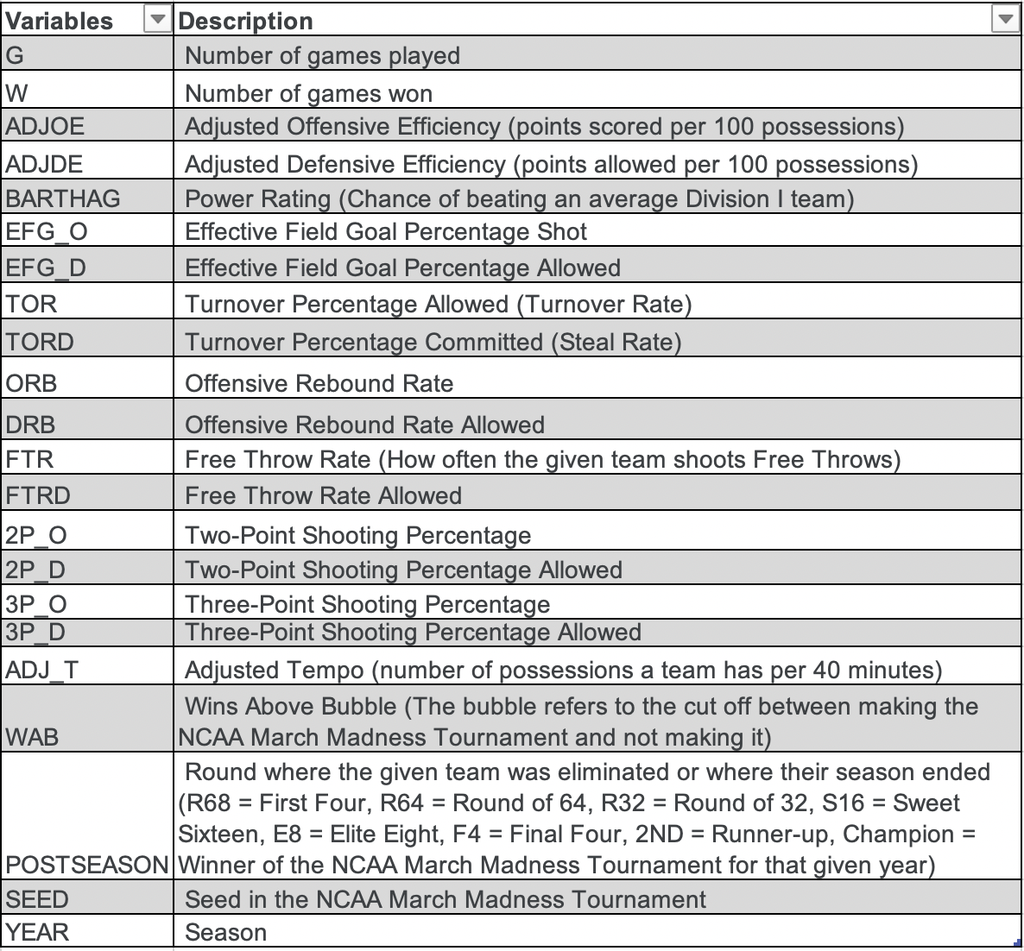

The following plot shows correlations of each variable with all other variables.

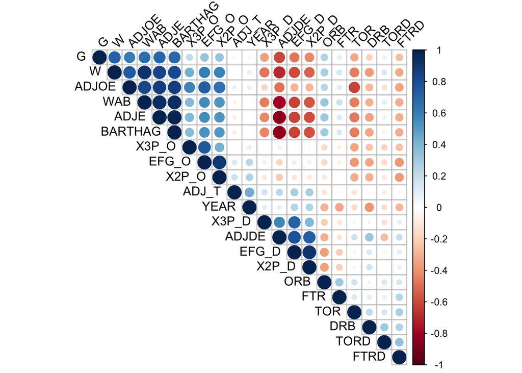

At first, I tried using t-tests to see whether each variable is correlated with if a team is a Bubble team. For instance, we found that the p-value for the number of wins is $2.2*10^{-16}$. Thus, the null hypothesis is rejected, meaning a Bubble team has more wins than a non-Bubble team in a regular season. Though it makes a lot of sense for this variable, by doing t-tests for other variables, I have come to realize that all null hypotheses are rejected except for year, seed, and postseason records, which either do not pass the t-test or contain NA values. From this, I realized that simply conducting t-tests would not give much information on differences between Bubble teams and non-Bubble teams. The following scatterplot shows the correlation between every team’s adjusted efficiency and the number of wins. However, after plotting more graphs, I have realized that correlations between a lot of variables are strong and linear, meaning simple linear regression models are not beneficial enough to discover deep findings with this dataset. Thus, I have decided on other regularization techniques, such as Lasso and Ridge Regressions, to help gain more insights.

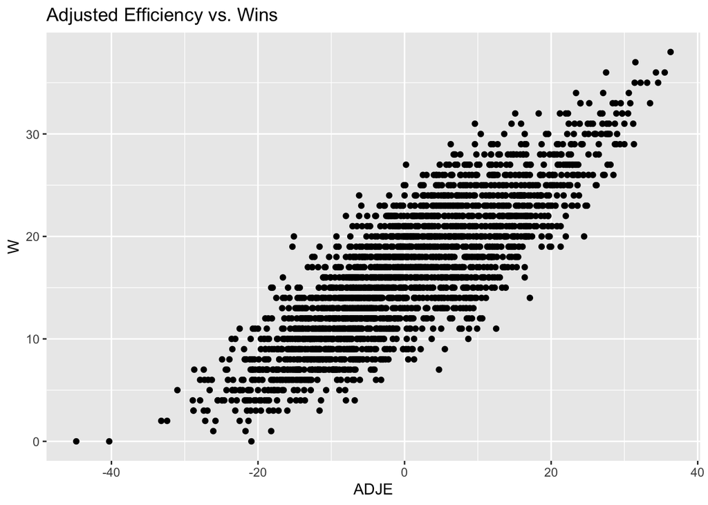

## Important Variables

After conducting t-tests, I have decided to use Backward Selection to choose which variables are important to predict a team’s postseason records (March Madness results). The reason Backward Selection Stepwise Regression model was chosen, instead of the AIC model, is that it is crucial to understand how each variable is eliminated each step. During the Backward Selection process, three-point shooting percentage, year (season), effective field goal percentage allowed, free throw rate allowed, adjusted tempo, seed, two-point shooting percentage, two-point shooting percentage allowed, offensive-rebound rate, three-point shooting percentage allowed, turnover rate committed, effective field goal percentage shot, and turnover rate are eliminated respectively to avoid the problem of statistically significance. As a result, the model computed that a prediction of the March Madness Tournament results could be calculated by $postseason = -8.23366 + 22.07952*W_percent - 3.08449*ADJOE + 2.99657*ADJDE + 151.82153*BARTHAG - 0.3915*DRB + 0.20143*FTR - 3.17840*WAB$.

## Lasso, Mixed, and Ridge Regression

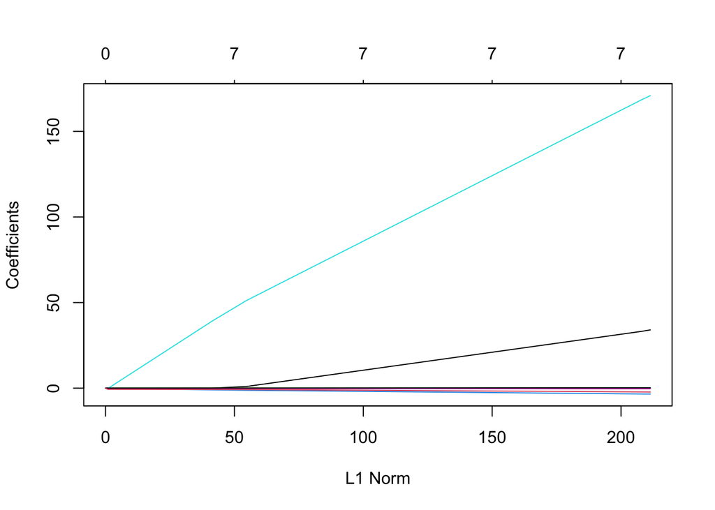

## Summary

Although the results suggest that it is inaccurate to attempt to predict a team’s journey in the March Madness Tournament given the regression model I have computed, this project does turn out supporting the unpredictability of college basketball, which is what makes the game much more than just statistics and numbers. As mentioned before, analyzing more of the college basketball data can help spark potential research ideas while also providing insights on modern-age basketball to stimulate its growth as a sports. Coaches can also use such ideas to strategize and help their teams play on the next level.